# ALY6040 M2 Technique Practice - Classification Tree

Instructor: Dr. Marcus Ellis

Student: Shahabaddin Feghahati

Completion Date: 03/04/2023

#### Analysis

```r
#Installing libraries
#install.packages('rpart')
#install.packages('caret')
#install.packages('rpart.plot')
#install.packages('rattle')
#install.packages('readxl')

#Loading libraries
library(rpart,quietly = TRUE)
library(caret,quietly = TRUE)
library(rpart.plot,quietly = TRUE)
library(rattle)
library(readxl)
```

#### *CODE WALK THROUGH*

The code above installs and loads several R packages that will be used in subsequent code. Note that these libraries are used for machine learning and data analysis tasks (Contributed packages, n.d.).

```r
#Reading the data set as a dataframe
mushrooms <- read_excel("mushrooms.xlsx")
```

#### *CODE WALK THROUGH*

The line above reads an Excel file called “mushrooms.xlsx” and stores its contents as a data frame called mushrooms.

```r
# structure of the data
str(mushrooms)
```

```
## tibble [8,124 × 23] (S3: tbl_df/tbl/data.frame)
##  $ class                   : chr [1:8124] "p" "e" "e" "p" ...
##  $ cap-shape               : chr [1:8124] "x" "x" "b" "x" ...
##  $ cap-surface             : chr [1:8124] "s" "s" "s" "y" ...
##  $ cap-color               : chr [1:8124] "n" "y" "w" "w" ...
##  $ bruises                 : chr [1:8124] "t" "t" "t" "t" ...
##  $ odor                    : chr [1:8124] "p" "a" "l" "p" ...
##  $ gill-attachment         : chr [1:8124] "f" "f" "f" "f" ...
##  $ gill-spacing            : chr [1:8124] "c" "c" "c" "c" ...
##  $ gill-size               : chr [1:8124] "n" "b" "b" "n" ...
##  $ gill-color              : chr [1:8124] "k" "k" "n" "n" ...
##  $ stalk-shape             : chr [1:8124] "e" "e" "e" "e" ...
##  $ stalk-root              : chr [1:8124] "e" "c" "c" "e" ...
##  $ stalk-surface-above-ring: chr [1:8124] "s" "s" "s" "s" ...
##  $ stalk-surface-below-ring: chr [1:8124] "s" "s" "s" "s" ...
##  $ stalk-color-above-ring  : chr [1:8124] "w" "w" "w" "w" ...
##  $ stalk-color-below-ring  : chr [1:8124] "w" "w" "w" "w" ...
##  $ veil-type               : chr [1:8124] "p" "p" "p" "p" ...
##  $ veil-color              : chr [1:8124] "w" "w" "w" "w" ...
##  $ ring-number             : chr [1:8124] "o" "o" "o" "o" ...
##  $ ring-type               : chr [1:8124] "p" "p" "p" "p" ...
##  $ spore-print-color       : chr [1:8124] "k" "n" "n" "k" ...
##  $ population              : chr [1:8124] "s" "n" "n" "s" ...
##  $ habitat                 : chr [1:8124] "u" "g" "m" "u" ...
```

#### *CODE WALK THROUGH*

The line str(mushrooms) provides a quick and concise way to inspect the structure of a data frame in R (Run R code online, n.d.).

#### *BRIEF DESCRIPTION OF MUSHROOM DATASET*

The data contains information about mushrooms and has 8,124 rows and 23 columns. Each row represents a different mushroom and each column represents a different characteristic of the mushroom such as its shape, color, odor, and habitat. The ‘class’ column indicates whether the mushroom is poisonous or edible, denoted by ‘p’ and ‘e’ respectively. The data seems to be categorical since all the columns are of the ‘chr’ type, indicating that they are character strings.

```r
# number of rows with missing values
nrow(mushrooms) - sum(complete.cases(mushrooms))
```

```
## [1] 0
```

#### *CODE WALK THROUGH*

The code above calculates the number of rows in the mushrooms data frame that have missing values by subtracting the number of complete rows from the total number of rows in the data frame (Run R code online, n.d.).

```r
# deleting redundant variable `veil.type`
mushrooms$veil.type <- NULL
```

#### *CODE WALK THROUGH*

```r
#analyzing the odor variable
table(mushrooms$class,mushrooms$odor)
```

```
##
##        a    c    f    l    m    n    p    s    y
##   e  400    0    0  400    0 3408    0    0    0
##   p    0  192 2160    0   36  120  256  576  576
```

```r
number.perfect.splits <- apply(X=mushrooms[-1], MARGIN = 2, FUN = function(col){
  t <- table(mushrooms$class,col)
  sum(t == 0)
})

# Descending order of perfect splits
order <- order(number.perfect.splits,decreasing = TRUE)
number.perfect.splits <- number.perfect.splits[order]
```

#### *CODE WALK THROUGH*

The code above first creates a table showing the frequency of each combination of “class” and “odor” in the dataset. It then calculates the number of “perfect splits” each column in the dataset can achieve when used to separate the two classes of mushrooms based on their odor. Finally, it sorts the columns in descending order based on their number of perfect splits, allowing for identification of the most useful variables for separating the two classes of mushrooms based on their odor.

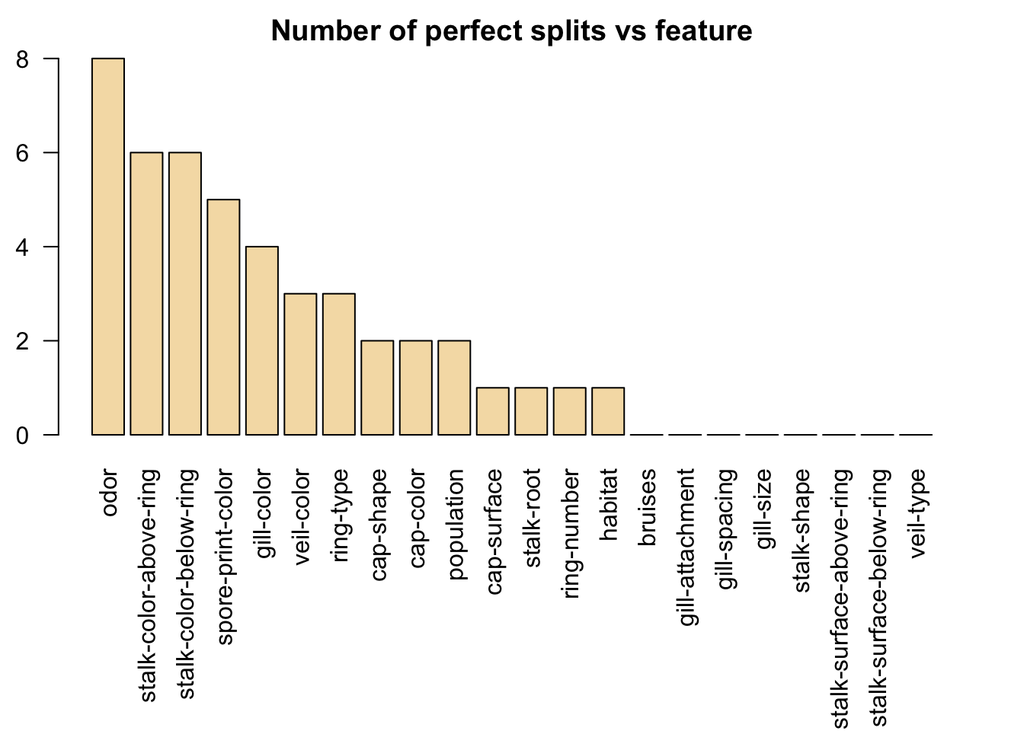

```r
# Plot graph
par(mar=c(10,2,2,2))
barplot(number.perfect.splits,
        main="Number of perfect splits vs feature",
        xlab="",ylab="Feature",las=2,col="wheat")
```

#### *CODE WALK THROUGH*

This code above creates a bar plot to visualize the number of “perfect splits” for each feature in the dataset.

#### *OBSERVATION*

The result shows the number of perfect splits for each variable in the mushroom dataset, with odor having the most perfect splits followed by stalk-color-above-ring and stalk-color-below-ring. This suggests that these variables are good candidates for splitting the dataset into different classes in a classification tree. Variables such as veil-type, gill-spacing, gill-size, stalk-shape, stalk-surface-above-ring, and stalk-surface-below-ring have zero perfect splits and may not be useful in splitting the dataset. The result can guide the selection of variables for a classification model and assess their importance in predicting the class of a mushroom.

```r
#data splicing
set.seed(12345)
train <- sample(1:nrow(mushrooms),size = ceiling(0.80*nrow(mushrooms)),replace = FALSE)
# training set
mushrooms_train <- mushrooms[train,]
# test set
mushrooms_test <- mushrooms[-train,]
```

#### *CODE WALK THROUGH*

The code above performs a simple random sampling operation to split the mushrooms dataset into a training set containing 80% of the data and a test set containing the remaining 20%.

```r
# penalty matrix
penalty.matrix <- matrix(c(0,1,10,0), byrow=TRUE, nrow=2)

# building the classification tree with rpart
tree <- rpart(class~.,
              data=mushrooms_train,
              parms = list(loss = penalty.matrix),
              method = "class")

# tabulating the result
#table(tree$frame$var, tree$frame$yval)
#summary(tree)# Tabulate the result
#printcp(tree)
```

#### *CODE WALK THROUGH*

The code above creates a classification tree model with a custom penalty matrix that assigns different penalties to different types of misclassifications (false negatives have a penalty of 1, false positives have a penalty of 10 and correct predictions have no penalty). The resulting model can be used to predict the class of mushrooms and assess the risk of making different types of misclassifications. The ‘parms’ argument specifies additional parameters, with ‘loss = penalty.matrix’ indicating use of the custom penalty matrix from previous step.

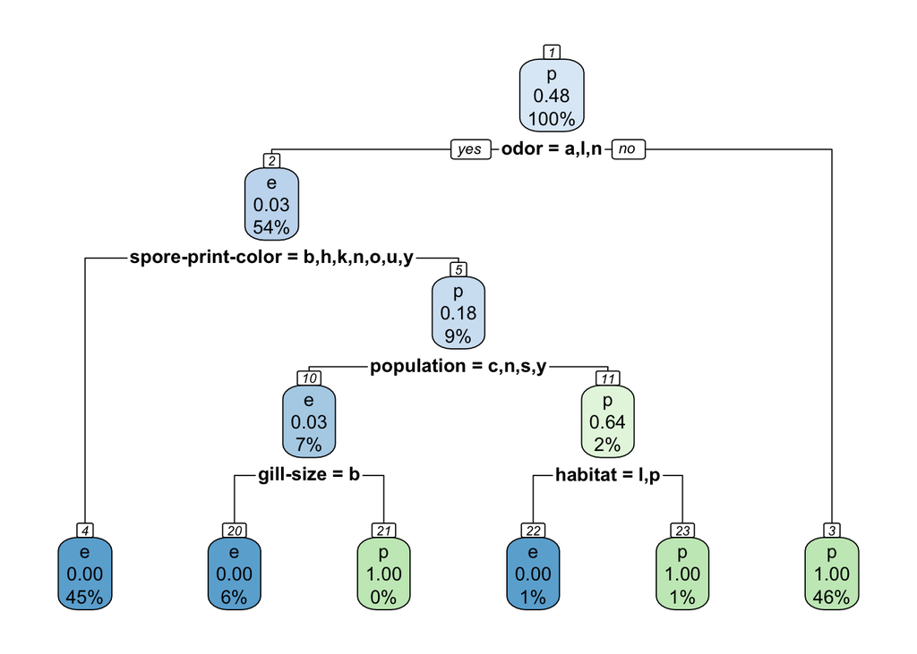

```r
# Visualize the decision tree with rpart.plot
rpart.plot(tree, nn=TRUE)
```

#### *OBSERVATION*

The tree is a flowchart-like structure that represents the different decisions that the model makes to classify mushrooms as either poisonous or edible. At each decision point, the tree considers a specific feature of the mushroom (e.g., odor, spore-print-color, population, gill-size, habitat) and makes a decision based on the value of that feature. Here is how to interpret the decision tree in the context of a mushroom dataset (Introduction to R: Decision trees, n.d.):

1. The first decision is based on the odor of the mushroom. If the odor is not ‘a’, ‘l’, or ‘n’, the mushroom is classified as poisonous, and the decision-making process stops. Otherwise, the model moves on to the next decision.
2. The second decision is based on the spore print color of the mushroom. If the spore print color is ‘b’, ‘h’, ‘k’, ‘n’, ‘o’, ‘u’, or ‘y’ the mushroom is classified as edible, and the decision-making process stops. Otherwise, the model moves on to the next decision.
3. The third decision is based on the mushroom’s population. If it’s not ‘c’, ‘n’, ‘s’, or ‘y’, the probability of it being poisonous is 0.64; otherwise, the probability is 0.03. The model then moves to the next decision in both cases.
4. The fourth decision is based on the size of the mushroom’s gills. If the gills are ‘b’, the mushroom is classified as edible, and the decision-making process stops. Otherwise, the mushroom is classified as poisonous.
5. The fifth and final decision is based on the habitat of the mushroom. If the habitat is ‘l’ or ‘p’, the mushroom is classified as edible. Otherwise, the mushroom is classified as poisonous and the decision-making process stops.

Overall, the decision tree provides a set of rules that can be used to predict whether a mushroom is poisonous or not based on its features. By following the decision path from the root node to the leaves, you can determine the final prediction for any given mushroom.